# NLP Lab1 - Regular expressions (aka regex)

**Author: Bartłomiej Jamiołkowski**

A FIQA-PL dataset containing Polish questions and answers is available at [Huggigface](https://huggingface.co/datasets/clarin-knext/fiqa-pl). In this lab we only concentrate on the `corpus` split of the dataset.

```python
from datasets import load_dataset
import matplotlib.pyplot as plt
import numpy as np
import pandas as pd
import calendar
from translate import Translator
from collections import Counter
from datetime import datetime
from babel.dates import format_date, get_month_names
import re
import warnings
warnings.filterwarnings('ignore')
```

```python
fiqa_pl = load_dataset('clarin-knext/fiqa-pl', 'corpus')
fiqa_pl_df = fiqa_pl['corpus'].to_pandas()
```

```python
fiqa_pl_df.head(5)
```

|  | _id | title | text |
| --- | --- | --- | --- |
| 0 | 3 |  | Nie mówię, że nie podoba mi się też pomysł szk... |
| 1 | 31 |  | Tak więc nic nie zapobiega fałszywym ocenom po... |
| 2 | 56 |  | Nigdy nie możesz korzystać z FSA dla indywidua... |
| 3 | 59 |  | Samsung stworzył LCD i inne technologie płaski... |
| 4 | 63 |  | Oto wymagania SEC: Federalne przepisy dotycząc... |

```python
fulltext = fiqa_pl_df['text'].str.cat(sep=' ')
```

## Task 1

Devise two regular expressions:  
extracting times, e.g. recognizing 20:30 as an instance of a time.  
extracting dates, e.g. recognizing 20 września as an instance of a date.

**times**  
In the frame of this task I decided to recognize the folowing time formats: HH:MM, HH:MM:SS, H:MM, H:MM:SS in 12-hour and 24-hour formats.

```python
time_pattern = r'\b([01]\d|[1-9]|2[0-3])(:[0-5]\d){1,2}\b'
```

**dates**

In the frame of the second part of this task I decided to recognize the following date formats: DD month YYYY, D month YYYY, DD MMM YYYY, D MMM YYYY, DD month, D month, YYYY-MM-DD, YYYY.MM.DD, YYYY/MM/DD, DD.MM.YYYY, DD/MM/YYYY, DD-MM-YYYY.

I wanted to create a more readable regular expression pattern for matching Polish month names. Instead of manually writing all the different forms, I decided to automate this process. First, I created a list of Polish months based on data from the calendar. Then, I found a way to obtain the genitive forms of these months by using babel.dates. Finally, I managed to obtain abbreviated forms of the Polish months. I joined all the lists and created a list that is applied in regex through regex concatenation.

```python
translator = Translator(to_lang='pl')
months_pl = list(map(lambda m: translator.translate(m).lower(), list(calendar.month_name)[1:]))
print(months_pl)
```

```
['styczeń', 'luty', 'marzec', 'kwiecień', 'maj', 'czerwiec', 'lipiec', 'sierpień', 'wrzesień', 'październik', 'listopad', 'grudzień']
```

```python
months_genitive_pl = list(get_month_names(width='wide', locale='pl_PL').values())
print(months_genitive_pl)
```

```
['stycznia', 'lutego', 'marca', 'kwietnia', 'maja', 'czerwca', 'lipca', 'sierpnia', 'września', 'października', 'listopada', 'grudnia']
```

```python
months_abbreviated_pl = list(get_month_names(width='abbreviated', locale='pl_PL').values())
print(months_abbreviated_pl)
```

```
['sty', 'lut', 'mar', 'kwi', 'maj', 'cze', 'lip', 'sie', 'wrz', 'paź', 'lis', 'gru']
```

```python
months_joined_pl = '|'.join(months_pl + months_genitive_pl + months_abbreviated_pl)
months_joined_pl
```

```
'styczeń|luty|marzec|kwiecień|maj|czerwiec|lipiec|sierpień|wrzesień|październik|listopad|grudzień|stycznia|lutego|marca|kwietnia|maja|czerwca|lipca|sierpnia|września|października|listopada|grudnia|sty|lut|mar|kwi|maj|cze|lip|sie|wrz|paź|lis|gru'
```

```python
date_pattern = r'\b((?:0[1-9]|[12]\d|3[01])[./-](?:0[1-9]|1[0-2])[./-](?:(?!0000)\d{4}))|((?:(?!0000)\d{4})[./-](?:0[1-9]|1[0-2])[./-](?:0[1-9]|[12]\d|3[01]))|((?:0?[1-9]|[12]\d|3[01]) (?:' + months_joined_pl + r')(?: (?!0000)\d{4})?)\b'
```

## Task 2

Search for occurrences of times and dates in the dataset.

**times**

```python
times = re.findall(time_pattern, fulltext)
times = [''.join(t) for t in times]
times[:15]
```

```
['17:23',
 '17:23',
 '6:17',
 '20:00',
 '17:00',
 '22:00',
 '12:00',
 '17:33',
 '15:00',
 '5:35',
 '8:00',
 '20:00',
 '12:03',
 '5:52',
 '17:00']
```

At this point, I have checked all the results, which indicate that the only times found in the fulltext are in HH:MM and H:MM formats. To ensure that the results are correct, I tested the regular expression on a recommended website https://regex101.com/ with all considered time formats. Additionally, I am checking whether there are longer formats than 5 digits (HH:MM)..

```python
any([len(time_str) > 5 for time_str in times])
```

```
False
```

**dates**

```python
dates = re.findall(date_pattern, fulltext)
dates = [''.join(d) for d in dates]
dates[:15]
```

```
['1 czerwca',
 '1 sierpnia',
 '1 sierpnia',
 '2017-10-06',
 '2017-10-06',
 '2 kwietnia 2018',
 '30 kwietnia 2018',
 '2017/09/09',
 '2009/07/09',
 '1 grudnia',
 '1 grudnia',
 '2017/01/02',
 '4 maja 1972',
 '2 marca 1975',
 '18 lipca 1979']
```

## Task 3

Plot results from point 2:  
for times create a bar plot for full hours.  
for dates create a bar plot for months.

**times**

In order to plot full hours obtained from different time formats I had to standardize obtained results (I enhanced HH:MM format).

```python
times = ['0' + time_str if len(time_str) == 4 else time_str for time_str in times]
```

```python
hours_counts_dict = dict(Counter([time_str.split(':')[0] + ':00' for time_str in times]))
hours_counts_df = pd.DataFrame(hours_counts_dict.items(), columns=['hour', 'count'])
hours_counts_df = hours_counts_df.sort_values(by='hour').reset_index(drop=True)
```

```python
hours_counts_df.head()
```

|  | hour | count |
| --- | --- | --- |
| 0 | 00:00 | 8 |
| 1 | 01:00 | 28 |
| 2 | 02:00 | 28 |
| 3 | 03:00 | 17 |
| 4 | 04:00 | 24 |

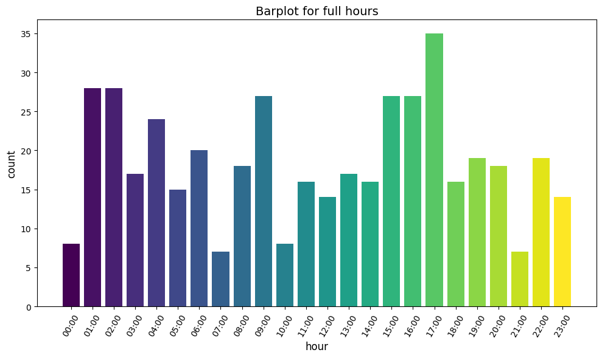

```python
colors = plt.cm.viridis(np.linspace(0, 1, len(hours_counts_df)))

plt.figure(figsize=(10, 6))
plt.bar(hours_counts_df['hour'], hours_counts_df['count'], color=colors)
plt.xticks(rotation=60)
plt.xlabel('hour', fontsize=12)
plt.ylabel('count', fontsize=12)
plt.title('Barplot for full hours', fontsize=14)
plt.tight_layout()
plt.show()
```

**dates**

In order to plot months obtained from different date formats I had to standardize obtained results (I enhanced standard Polish months names).

```python
months_pl_dict = {name:list(set([str(num + 1), '0' + str(num + 1) if num + 1 < 10 else str(num + 1), gen, abbr]))
                  for num, (name, gen, abbr) in enumerate(zip(months_pl, months_genitive_pl, months_abbreviated_pl))}

months_pl_dict
```

```
{'styczeń': ['stycznia', 'sty', '1', '01'],
 'luty': ['lut', '2', '02', 'lutego'],
 'marzec': ['03', 'marca', 'mar', '3'],
 'kwiecień': ['kwietnia', 'kwi', '04', '4'],
 'maj': ['5', 'maj', '05', 'maja'],
 'czerwiec': ['06', 'cze', '6', 'czerwca'],
 'lipiec': ['7', '07', 'lip', 'lipca'],
 'sierpień': ['sierpnia', '08', '8', 'sie'],
 'wrzesień': ['wrz', 'września', '9', '09'],
 'październik': ['października', 'paź', '10'],
 'listopad': ['lis', 'listopada', '11'],
 'grudzień': ['12', 'gru', 'grudnia']}
```

```python
def get_key_by_value(months_dict, month_format):
    for standard_month_name, month_formats_list in months_dict.items():
        if month_format in month_formats_list:
            return standard_month_name
    return month_format # it is already key (standard Polish month name)
```

```python
months = list(map(lambda d: get_key_by_value(months_pl_dict, re.split(r'[/.\- ]', d)[1]), dates))
```

```python
months_counts_dict = dict(Counter(months))
months_counts_df = pd.DataFrame(months_counts_dict.items(), columns=['month', 'count'])
months_counts_df['month'] = pd.Categorical(months_counts_df['month'], categories=months_pl, ordered=True)
months_counts_df = months_counts_df.sort_values(by='month').reset_index(drop=True)
```

```python
months_counts_df.head()
```

|  | month | count |
| --- | --- | --- |
| 0 | styczeń | 265 |
| 1 | luty | 119 |
| 2 | marzec | 156 |
| 3 | kwiecień | 259 |
| 4 | maj | 168 |

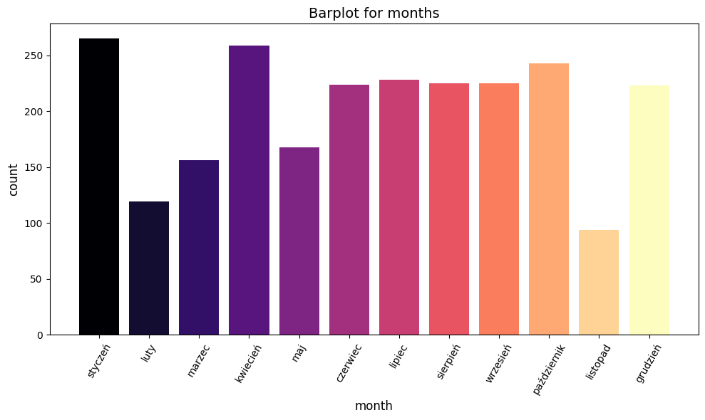

```python
colors = plt.cm.magma(np.linspace(0, 1, len(months_counts_df)))

plt.figure(figsize=(10, 6))
plt.bar(months_counts_df['month'], months_counts_df['count'], color=colors)
plt.xticks(rotation=60)
plt.xlabel('month', fontsize=12)
plt.ylabel('count', fontsize=12)
plt.title('Barplot for months', fontsize=14)
plt.tight_layout()
plt.show()
```

## Task 4

Compute the number of occurrences of kwiecień word in any inflectional form. Use a compact form for the query (i.e. joining all forms of the word by alternative is forbidden).

```python
kwiecien_pattern = r'\bkwie[ct][in][ei][ńaoeuó]?[wmc]?[ih]?(?<!cie)\b'
```

```python
kwieciens = re.findall(kwiecien_pattern, fulltext)
print(set(kwieciens))
```

```
{'kwiecień', 'kwietnia', 'kwietniem', 'kwietniu'}
```

```python
kwieciens_counts_dict = dict(Counter(kwieciens))
kwieciens_counts_df = pd.DataFrame(kwieciens_counts_dict.items(), columns=['kwiecień inflectional form', 'count'])
kwieciens_counts_df
```

|  | kwiecień inflectional form | count |
| --- | --- | --- |
| 0 | kwietnia | 235 |
| 1 | kwietniu | 99 |
| 2 | kwiecień | 14 |
| 3 | kwietniem | 2 |

```python
len(kwieciens)
```

```
350
```

## Task 5

As in 4, but preceded by a number and a space.

```python
num_kwiecien_pattern = r'\b\d{1,2} kwie[ct][in][ei][ńaoeuó]?[wmc]?[ih]?(?<!cie)\b'
```

```python
num_kwieciens = re.findall(num_kwiecien_pattern, fulltext)
print(set(num_kwieciens))
```

[output not shown]

```python
len(num_kwieciens)
```

```
201
```

## Task 6

As in 4, but not preceded by a number and a space. Check if the results from 5 and 6 sum to 4.

```python
without_num_kwiecien_pattern = r'\b(?<![0-9] )kwie[ct][in][ei][ńaoeuó]?[wmc]?[ih]?(?<!cie)\b'
```

```python
without_num_kwieciens = re.findall(without_num_kwiecien_pattern , fulltext)
print(set(without_num_kwieciens))
```

```
{'kwiecień', 'kwietnia', 'kwietniem', 'kwietniu'}
```

```python
len(without_num_kwieciens)
```

```
149
```

```python
len(num_kwieciens) + len(without_num_kwieciens) == len(kwieciens)
```

```
True
```

Obtained results lengths of lists indicate that results from 5 and 6 sum to 4 (201 + 149 = 350)

## Task 7

Ask an LLM (e.g. [Bielik](https://chat.bielik.ai/)) to complete these tasks for you. Compare and criticize the code generated by the LLM.

First I tried to use Bielik during weekend, but it turned out that there was some kind of error. As a result, I and other asked students were getting message: 'Błąd generowania odpowiedzi :-('. In such situation I used another LLM called Gemini 1.5 Flash model provided by Google. I had sent information about dataset and I started giving tasks to mentioned model.  
**Repeated Task 1**

[figure not shown]

The first obtained result is very simple and cannot find appropriate time formats. In my solution, I tried to cover this topic as much as possible and do everything to avoid inappropriate values.

The second printed result has similar cons as the previous one. It is only focused on provided example date format. In my code, I tried to find multiple date formats. I also took some steps to eliminate invalid values occurrences in results of my code.

**Repeated Task 2**

[figure not shown]

The suggested solution to this task is time-consuming and does not store results in variables. Instead of using loop, I created fulltext and variables, which enable me to do further operations.

**Repeated Task 3**

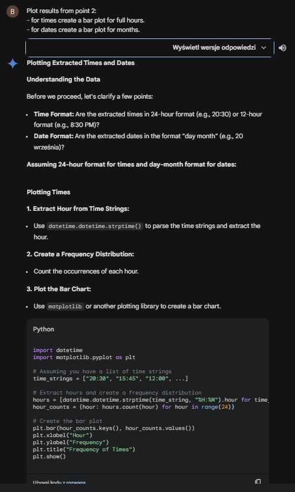

Gemini model suggested to use time format HH:MM in order to visualize results. Well, I found different time formats, so I had to standardize the time format in order to plot counted results. What's more, the model did not understand the given task, because it did not plot full hours, e.g 12:00. Model's solution printed integer hours instead of full hours. The model and I used a dictionary in order to store counts of different hours. However, I used a Counter from collections, whereas the model created a list of integers and then counted occurrences of integers in this list.

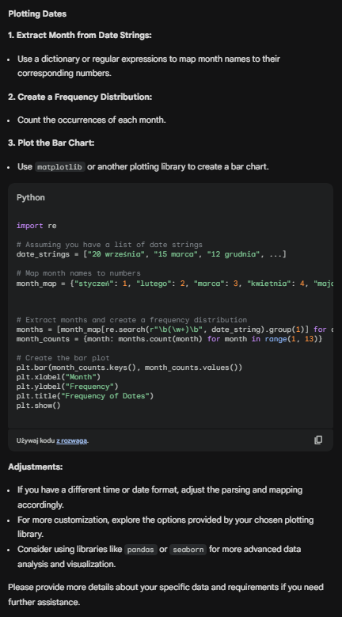

Similar situation is in the second part of this task, where the model finally used regex. However, this regular pattern is weird, and it is very possible that in full text it would return many inappropriate results (there is different order of d\data collection then in this laboratory).

**Repeated Task 4**

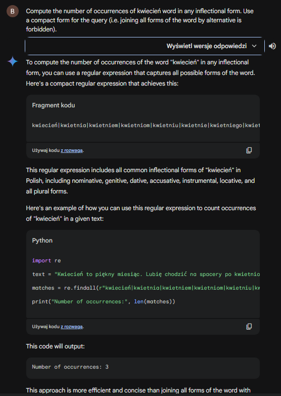

This task was done completely wrong by mentioned model. Instead of avoiding joining forms of the word by alternative, it actually did it. In contrast, I created my regular pattern without a usage of alternative and using other forms of word kwiecień.

**Repeated Task 5**

[figure not shown]

My regular pattern and pattern provided by Gemini differ a lot. First, it copies a bad solution from a previous task, and then it searches occurrences of kwiecień forms preceded by a single number and space. In contrast, I was looking for one or two numbers e.g 01 or 25.

**Repeated Task 6**

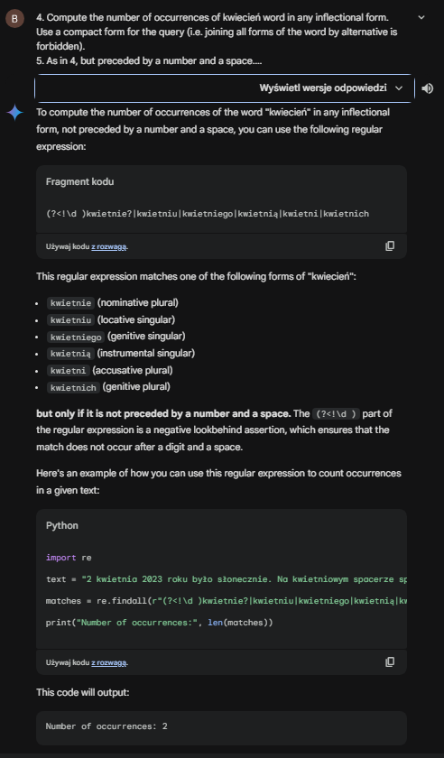

Gemini did this task completely wrong. Despite the fact, I provided all 3 task descriptions for him, it did not check if sum of results of tasks 5 and 6 sum to result of task 4. I did it and proved it worked.

Summarizing, I recommend developing own ideas how to solve given problems. In my opinion, Gemini's performance was unsatisfactory.

## Question 1

Are regular expressions good at capturing times?

In my opinion, regular expressions are effective at capturing times in different formats, provided they are well-defined and free from ambiguities. However, there is always possibility that rare time formats, such as scientific and informal, can occur.

## Question 2

Are regular expressions good at capturing dates?

From my point of view, regular expressions are good at capturing dates. However, I find this task more difficult than finding times. My opinion is based on the fact that date formats tend to be more complex than time formats. During my research on this topic, I had the sense that there are more date formats than time formats. Therefore, finding all date formats can be challenging and prone to more errors.

## Question 3

How one can be sure that the expression has matched all and only the correct expressions of a given type?

I believe there is always a probability that a regular expression may not match all and only the correct expressions of a given type. As a result, no one can be sure that his/her regular expressions are perfect. The only way to reduce risk of unmatched cases is testing and broadening knowledge about existing formats.

## Question 4

Is LLM able to generate regular expressions?

From my previous experience, I can confirm that LLMs are able to generate regular expressions, because they are trained on vast amounts of data provided by humans.